# EDAV Fall 2019 Problem Set 3

### 3. Heart Disease

Data: four data frames that begin with `heart_disease` in the **ucidata** package

Packages: You may use **vcd** or **ggmosaic**.

1. Create three mosaic plots, each involving two categorical variables from `heart_disease_cl` and interpret the plots. (You may reuse variables, for example X ~ Y and X ~ Z).

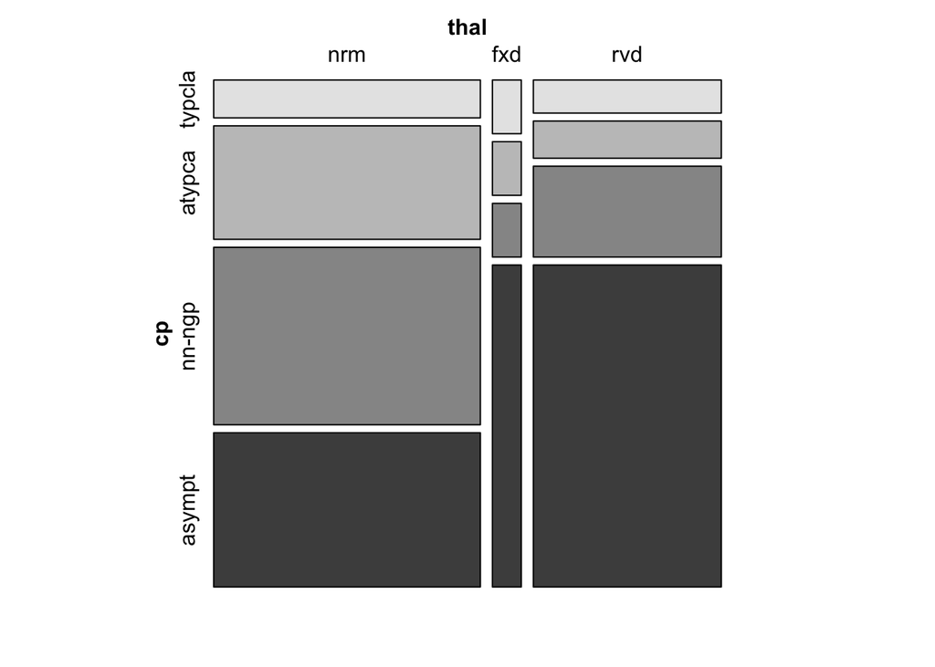

```r
library(ucidata)
library(vcd)

mosaic(cp ~ thal,
       direction = c('v','h'),
       labeling = labeling_border(
         abbreviate_labs = c(3, 6),
         rot_labels=c(0,90)
         ),
       spacing = spacing_increase(),
       heart_disease_cl)
```

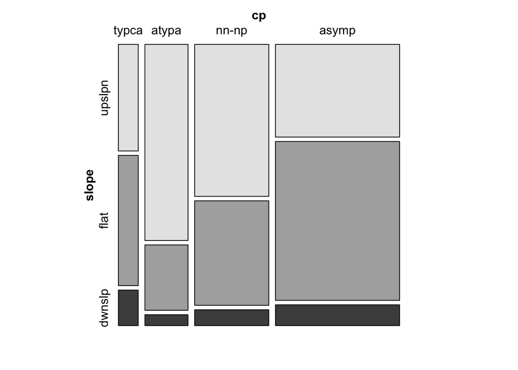

```r
mosaic(slope ~ cp,
       direction = c('v','h'),
       labeling = labeling_border(
         abbreviate_labs = c(5, 6),
         rot_labels=c(0,90)
         ),
       spacing = spacing_increase(),
       heart_disease_cl)
```

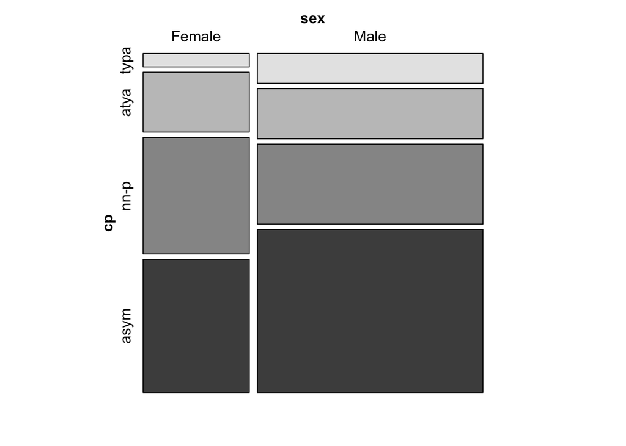

```r
mosaic(cp ~ sex,
       direction = c('v','h'),
       labeling = labeling_border(
         abbreviate_labs = c(6, 4),
         rot_labels=c(0,90)
         ),
       spacing = spacing_increase(),
       heart_disease_cl)
```

For the first plot, we see that most people have normal values for thal, some have reversable defects, and very few have fixed defects. For people with fixed and reversable defects, the majority of them have asympotatic chest pain. People with normal values for thal have the highest proportion of non-anginal pain.

For the second plot, we see that most people have asymptomatic chest pain, and the majority of people within that category have flat slopes of the peak exercise ST segment. Upsloping slopes are most common for people with atypical angina chest pain and non-anginal chest pain. Of all types of chest pain, typical angina chest pain is the least common. For the peak exercise ST segment, most people have either flat or upsloping slopes, and very few people see a downsloping trend.

For the third plot, we see that around 70% of our patients are male and 30% are female. For males, the most common chest pain type is asymptomatic. For females, there are similar proportions of non-anginal pain and asymptomatic pain. For both genders, typical angina chest pain is the most rare, and atypical angina chest pain is the second most rare.

2. Combine the four heart disease datasets and create a mosaic plot showing chest pain by sex and location. Describe any patterns.

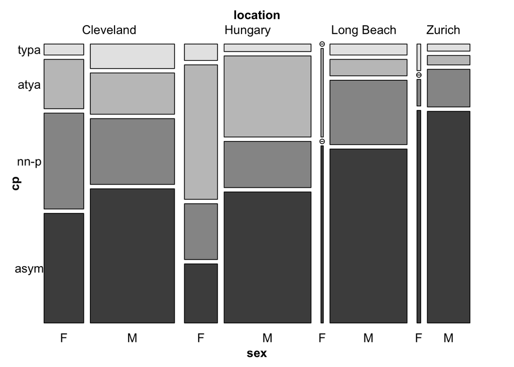

```r
heart <- rbind(heart_disease_ch %>% mutate(location = 'Zurich'),
               heart_disease_cl %>% mutate(location = 'Cleveland'),
               heart_disease_hu %>% mutate(location = 'Hungary'),
               heart_disease_va %>% mutate(location = 'Long Beach'))

mosaic(cp ~ location + sex ,
       heart,
       labeling = labeling_border(
         abbreviate_labs = c(10, 1, 4),
         rot_labels=c(0,0,0)),
       spacing = spacing_increase(),
       direction = c('v','v','h')
       )
```

The most noticeable pattern is that Long Beach and Zurich both have extremely low proportions of females compared to males. Cleveland and Hungary have the most patients. In every division of gender and location, we see that asymptomatic chestpain is the most common type of chest pain, except for females in Hungary, where the most common type of chest pain is atypical angina pain. In Cleveland and Hungary, we see that there’s a lower proportion of asymptomatic chest pain in females as compared to males, whereas in Long Beach and Zurich, the proportions are relatively equal. Also in every location, we see that there are fewer female patients than male.

### 4. District 3 Elementary Schools

Recently, there has been much debate about the lack of racial and economic diversity at Manhattan District 3 elementary schools, part of a larger and long-standing controversy about iniquities in the New York City public school system as a whole.

The *New York Times* article, “Rezoning Plan to Remake 3 Upper West Side Schools Will Proceed, City Says,” (https://www.nytimes.com/2016/11/10/nyregion/rezoning-plan-for-3-upper-west-side-schools-will-proceed-city-says.html) (2016-11-10) identifies the 11 elementary schools in Manhattan District 3.

For this question, we will analyze parent survey results for these schools.

Data: https://www.schools.nyc.gov/about-us/reports/school-quality/nyc-school-survey

1. Choose one of the likert style questions from the 2019 parent survey and use a diverging stacked bar chart to show results for the 11 schools identified in the article referenced above.

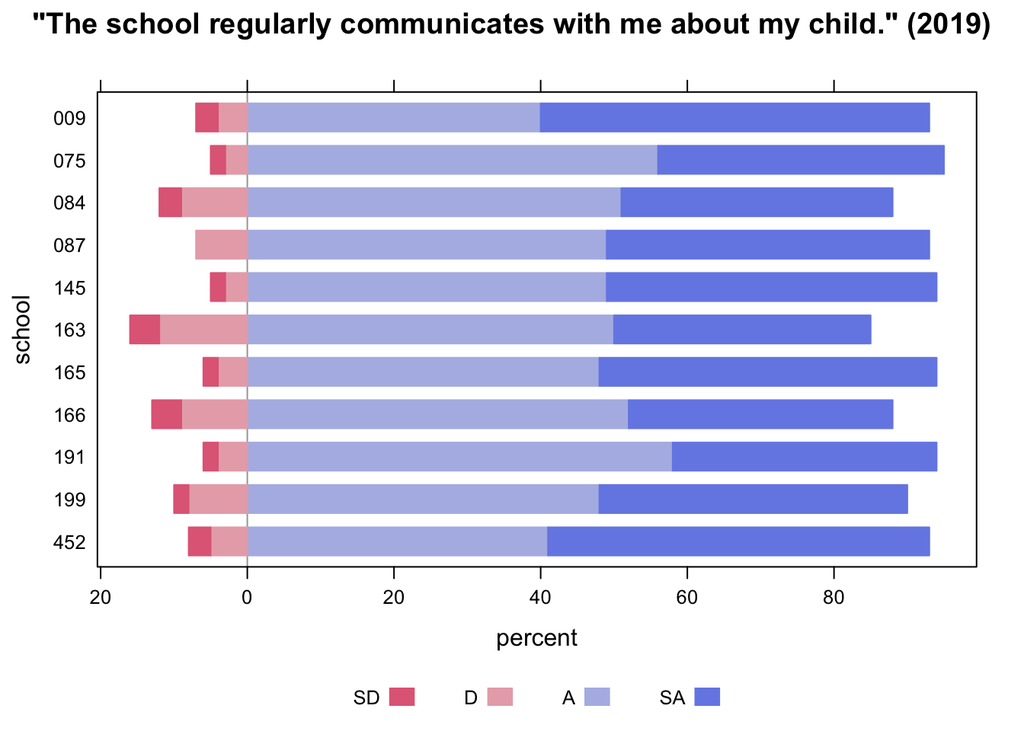

```r
library(readxl)
library(HH)

parent <- read_excel('parent.xlsx')

new <- parent %>%
  filter(str_sub(DBN,1,3) == '03M') %>%
  filter(str_sub(DBN,4,6) %in% c('009','165','145','163', '075', '084', '166', '087', '452', '199', '191')) %>%
  mutate(school = str_sub(DBN,4,6)) %>%
  dplyr::select('school'= school, 'SD' = 4, 'D' = 5, 'A' = 6, 'SA' = 7) %>%
  mutate_at(1, as.factor) %>%
  mutate_if(is.character, as.integer)

likert(school~., new, as.percent=FALSE, rightAxis = FALSE, main='"The school regularly communicates with me about my child." (2019)', xlab = 'percent')
```

2. Choose a question that was asked in 2014 and 2019 and compare results for the three schools discussed most in the article: P.S. 199, P.S. 191, and P.S. 452. You may use two separate diverging stacked bar charts or combine all the information in one.

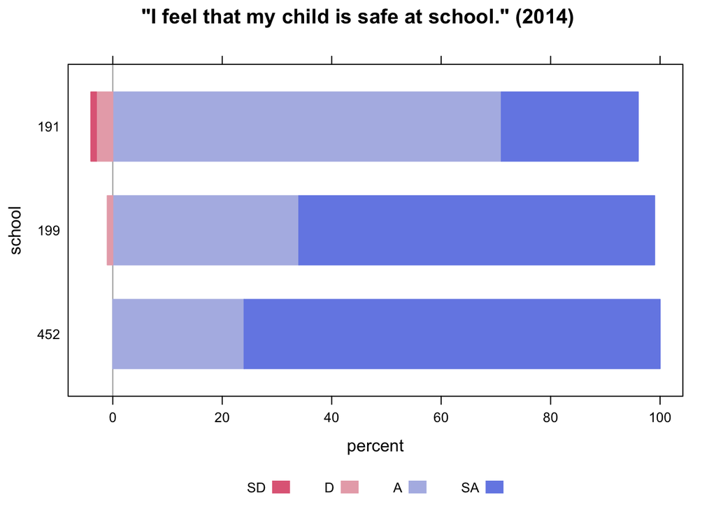

```r
parent2014 <- read_excel('2014parent.xlsx')

new2019 <- parent %>%
  filter(str_sub(DBN,1,3) == '03M') %>%
  filter(str_sub(DBN,4,6) %in% c('452', '199', '191')) %>%
  mutate(school = str_sub(DBN,4,6)) %>%
  dplyr::select('school'= school, 'SD' = 77, 'D' = 78, 'A' = 79, 'SA' = 80) %>%
  mutate_at(1, as.factor) %>%
  mutate_if(is.character, as.integer)

new2014 <- parent2014 %>%
  filter(str_sub(DBN,1,3) == '03M') %>%
  filter(str_sub(DBN,4,6) %in% c('452', '199', '191')) %>%
  mutate(school = str_sub(DBN,4,6)) %>%
  dplyr::select('school'= school, 'SD' = 67, 'D' = 66, 'A' = 65, 'SA' = 64) %>%
  mutate_at(1, as.factor) %>%
  mutate_if(is.character, as.integer)


likert(school~., new2014, as.percent=FALSE, rightAxis = FALSE, main='"I feel that my child is safe at school." (2014)', xlab = 'percent')
```

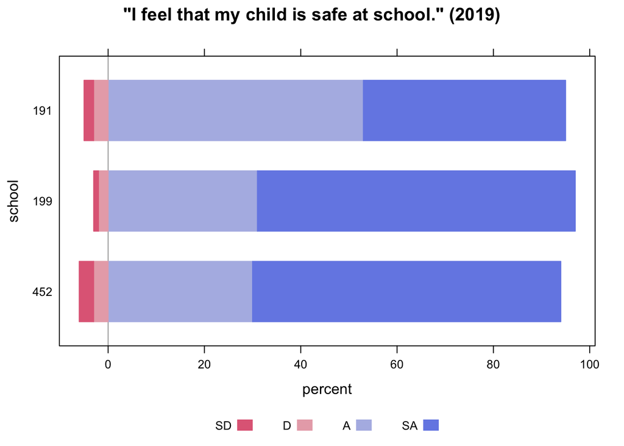

```r
likert(school~., new2019, as.percent=FALSE, rightAxis = FALSE, main='"I feel that my child is safe at school." (2019)', xlab = 'percent')
```

3. Interpret your findings of (b) in light of the reputations of the schools as presented in the article. Are they surprising or what you would have expected?

The 2014 reponses come from data prior to the school district voting on the resolutions to redistrict the schools in the Upper West Side. School 452 and 199 were identified as schools with predominantly well-off, white population. Many parents in these schools’ boundaries are the ones who threatened lawsuits in response to possible redistricting, so it is reasoned that this population would be comfortable with the current situation. This is mirrored in the dataset, showing that 100% of respondents from school 452 either agreed or strongly agreed that they felt their children were safe at school, and 99% of parents from School 199 felt the same way. School 191 was identified as being in a poorer minority neighborhood, but parents from this area still felt relatively safe, at a rate of 96%. However, following the redistricting, these valuations changed significantly. School 452 now has the highest rate of unsafe responses. This makes sense because the school was moved to the location of a school that parents from 452 originally felt was unsafe, so they are likely to feel relatively unsafe compared to the previous location. It also makes sense that the population of 452 parents whose children were moved to 191 and 199 would also feel relatively unsafe compared to their old situation. For this reason, it makes sense and is supported by the data that all three schools have a higher proportion of parents who feel relatively unsafer than they did prior to redistricting.